# Obtaining the EAF for the cross-tissue RP eQTL analysis in GTex

April 26, 2020

**Author: Charleen D. Adams**

## Abbreviations and definitions

- Gene-Tissue Expression (GTex) Project – database of tissue-specific gene expression and SNPs associated with gene expression
- Ribosomal protein (RP)
- expression quantitative trait loci (eQTL) – SNPs associated with gene expression
- significance threshold (Q-value for ‘eGene’ status <0.05 & nominal P<5x10-6) – analyses here use the set of GTex eQTLs meet this criteria
- Minor allele frequency (MAF)
- Effect allele frequency (EAF)

## Background

GTEx coded their eQTL analysis such that the effect allele is the alternate allele. But the alternate allele is not always the minor allele. The effect sizes (“betas”) for the eQTLs refer to the slope of the linear regressions “computed as the effect of the alternative allele (ALT) relative to the reference allele (REF) in the human genome reference (i.e., the eQTL effect allele is the ALT allele)” – which is not always the minor allele.

In order to know which of the alleles is the true minor allele, I needed to obtain annotation information for the SNPs.

## Goal

- Get annotation data from`SNPnexus`
- Calculate EAF
- Use`sqldf` to merge EAF back into the master RP dataset
- Provide statistics for the EAF for GTEx ribosomal protein eQTLs (threshold qval<0.05 & P<5x10-6)

## Total number of eQTLs across tissues (threshold qval<0.05 & P<5x10-6) and number of unique eQTLs

```r
# Total number eQTLs across the RP genes
dim(stringent_RP_sig_beta)
```

```
## [1] 2418   45
```

```r
# Number of unique eQTLs
snp=unique(stringent_RP_sig_beta$SNP)
length(snp)
```

```
## [1] 996
```

## Annotation from `SNPnexus`

[*SNPnexus*](https://www.snp-nexus.org/v4/) is an online annotation tool for SNPs (with an option for GRCh38/hg38).

I entered our list of 996 unique eQTLs (threshold qval<0.05 & P<5x10-6) into `SNPnexus` and obtained annotation data for which allele is the reference, alternate, and minor, along with the minor allele frequencey (MAF).

(Side note: Separate `SNPnexus` annotation files also provide genomic consequence and deleteriosness for these SNPs. I can make plots with this data later…)

## Determine EAF

```r
# Read in the dummy copy of the SNPnexus results called my_data2
my_data2 <- read.table("C:/Users/charl/Dropbox/Harvard/ribosomal_proteins/Main_Tables_Paper/v8/gen_coords_v8_unique.txt",
  header=TRUE, sep='\t',stringsAsFactors = FALSE)
# How many of the unique eQTLs can we annotate?

dim(my_data2)
```

```
## [1] 985  11
```

```r
985/996 #99%
```

```
## [1] 0.9889558
```

```r
# Create a dummy variable called "match" for whether the minor allele is the reference allele (1=yes)
my_data2<-within(my_data2, match <- ifelse (Minor.Allele == REF.Allele,1,0))
table(my_data2$match)
```

```
##
##   0   1
## 740 245
```

```r
# Create the EAF variable by reasoning that if the minor allele is the references allele, then
# 1) the EAF is 1-MAF for our data
# 2) otherwise, the EAF is the MAF

my_data2$Minor.Allele.Global.Frequency=as.numeric(my_data2$Minor.Allele.Global.Frequency)
my_data2$EAF <- my_data2$Minor.Allele.Global.Frequency
my_data2$EAF <- ifelse(my_data2$match=="1", 1-my_data2$Minor.Allele.Global.Frequency,
  my_data2$Minor.Allele.Global.Frequency)

my_data2$dbSNP=as.character(my_data2$dbSNP)

# sqldf to merge (ignore warning)
merged=sqldf("select *
  from stringent_RP_sig_beta left join my_data2
  on stringent_RP_sig_beta.SNP = my_data2.dbSNP",
  row.names = TRUE)
merged_EAF <- merged[order(merged$SNP),]
```

## Summary of EAF for GTEx ribosomal protein eQTLs

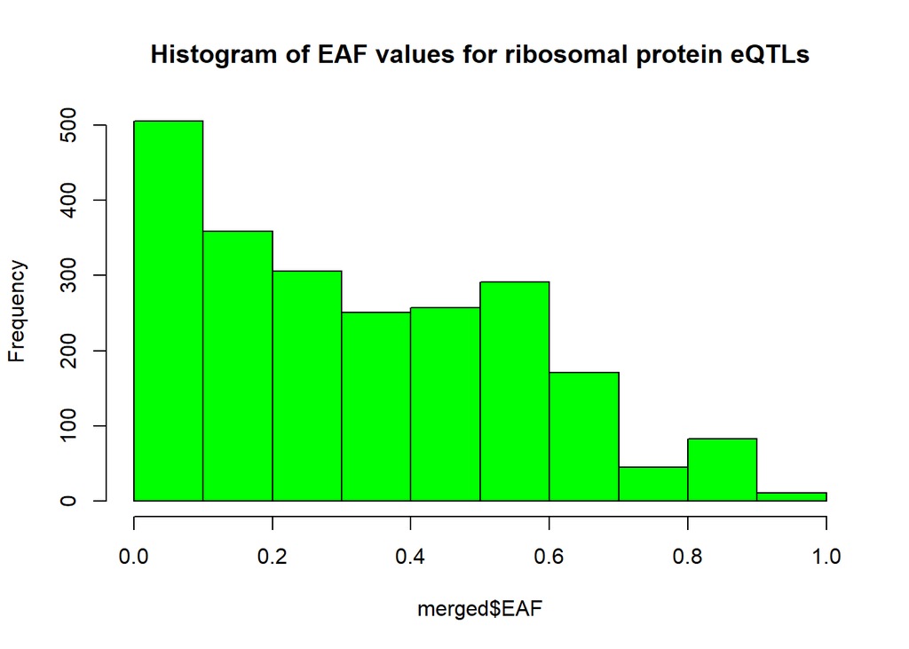

```r
hist(merged$EAF, col = c("green"),
     main="Histogram of EAF values for ribosomal protein eQTLs")
```

```r
summary(merged$EAF)
```

```
##    Min. 1st Qu.  Median    Mean 3rd Qu.    Max.    NA's
##  0.0024  0.1216  0.2919  0.3279  0.5132  0.9740     139
```

## Interactive table of the primary RP eQTL data (selected variables, including EAF)

In the table, “effect_allele” refers to the alternate allele in GTEx. The “other_allele” is the reference allele. The variable “match” signifies “1” when the reference allele is the minor allele and “0” when the alternate allele is the minor allele.

```r
library(DT)
my_table_cols=c('tissue','n','position','chr','gene_name','SNP', 'EAF','match','effect_allele', 'other_allele','beta','pval', 'qval','se' )
interactive_merged=merged[my_table_cols]

datatable(interactive_merged, options = list(pageLength = 5))
```

|  | tissue | n | position | chr | gene_name | SNP | EAF | match | effect_allele | other_allele | beta | pval | qval | se |
| --- | --- | --- | --- | --- | --- | --- | --- | --- | --- | --- | --- | --- | --- | --- |
| 481 | Adipose_Subcutaneous | 763 | 10259814 | chr19 | MRPL4 | rs1059840 | 0.133187 | 0 | A | T | 0.223401 | 1.27492e-19 | 1.43342e-14 | 0.0236552 |
| 820 | Adipose_Subcutaneous | 763 | 105063634 | chr2 | MRPS9 | rs12619915 | 0.171326 | 0 | G | A | -0.512455 | 3.30641e-41 | 1.30269e-34 | 0.0347793 |
| 1211 | Adipose_Subcutaneous | 763 | 108595388 | chr4 | RPL34 | rs28760069 | 0.031749 | 0 | T | C | -0.837832 | 2.06246e-17 | 3.72089e-13 | 0.0951737 |
| 2517 | Adipose_Subcutaneous | 763 | 119018475 | chr11 | RPS25 | rs11217125 | 0.270767 | 0 | C | T | -0.123885 | 1.30947e-11 | 8.37904e-08 | 0.017888 |
| 2709 | Adipose_Subcutaneous | 763 | 120206935 | chr8 | MRPL13 | rs143918652 | 0.010383 | 0 | A | T | -0.563411 | 3.34034e-07 | 0.000605693 | 0.108946 |
| 3456 | Adipose_Subcutaneous | 763 | 127458677 | chr9 | RPL12 | rs2243784 | 0.558906 | 1 | A | G | 0.378234 | 2.99403e-94 | 4.99251e-84 | 0.0147016 |
| 4614 | Adipose_Subcutaneous | 763 | 137549626 | chr9 | MRPL41 | rs10746563 | 0.478435 | 0 | C | T | -0.327227 | 4.61058e-38 | 2.92198e-32 | 0.0233224 |
| 4756 | Adipose_Subcutaneous | 763 | 139335827 | chr3 | MRPS22 | rs36177608 | 0.25599 | 0 | A | G | -0.136181 | 4.85353e-07 | 0.000745077 | 0.026715 |
| 4758 | Adipose_Subcutaneous | 763 | 139335827 | chr3 | MRPS22 | rs36177608 | 0.25599 | 0 | A | G | -0.136181 | 4.85353e-07 | 0.000745077 | 0.026715 |
| 4882 | Adipose_Subcutaneous | 763 | 1407232 | chr1 | MRPL20 | rs2275915 | 0.430312 | 0 | C | G | 0.280967 | 2.96095e-34 | 9.73256e-28 | 0.0213551 |

[output cut: 2408 more lines]

## Commentary on eQTL interactive table

- Most of the SNPs not annotated in `SNPnexus` appear to be small indels, except for one for prostate (row id=‘987634’) that is a long interspersed nuclear element (LINE), and oddly, is coded by GTEx as the reference. (It will get dropped in MR analyses for prostate.)
- I noticed one of the SNPs in the GTEx files was labeled with two rsids: rs4909,rs12012747. This meant it was not originally found in the `SNPnexus` lookup. I went in an verified that the two rsids refer to the same SNP and chose rs12012747 to label it in our master file.

## Data cleaning: one SNP in GTEx had two rsids

```r
merged_EAF=merged

#### One SNP has two rsids: change to the rsid that has MAF info: rs12012747
merged_EAF$SNP=as.character(merged_EAF$SNP)
merged_EAF$SNP=ifelse(merged_EAF$SNP=='rs4909,rs12012747', 'rs12012747', merged_EAF$SNP)
merged_EAF$match=ifelse(merged_EAF$SNP=='rs12012747', 0, merged_EAF$match)
merged_EAF$EAF=ifelse(merged_EAF$SNP=='rs12012747', 0.331126, merged_EAF$EAF)

### Rename the 'eaf' variable in the master file to reflect that it is the MAF in GTEx (not the actual EAF; the actual EAF is labled 'EAF')
colnames(merged_EAF)[31] <- "maf_in_GTEx"
write.csv(merged_EAF, 'merged_EAF.csv')
```

## Acknowledgement language for manuscript

‘The Genotype-Tissue Expression (GTEx) Project was supported by the Common Fund of the Office of the Director of the National Institutes of Health, and by NCI, NHGRI, NHLBI, NIDA, NIMH, and NINDS. The data used for the analyses described in this manuscript were obtained from: the GTEx Portal on 04/01/2020’

## Github

I’ve started a [*Github*](https://github.com/charleendadams/ribosomal_protein_eQTLs) repository to organize the files and scripts for this project. If Github refuses to open through the link, copy this link into your browser: https://github.com/charleendadams/ribosomal_protein_eQTLs